# Lindsay’s model

Michael Crawford

# 1 Biomass in monoculture vs. traits

First, a facetted plot of the relationship between each species’ trait values and the species’ monoculture biomass.

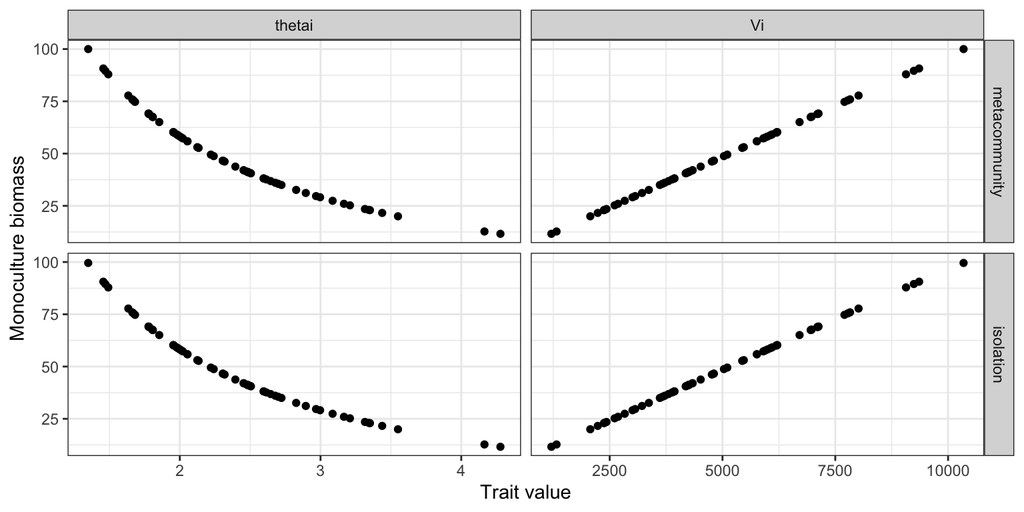

```r
monocultures <- lindsay %>%
    filter(Ninitial == 1,
           Year %in% c(100, 200)) %>%
    rename(monoculture.biomass = Biomass) %>%
    select(-Ninitial, -Year, -Rep) %>%
    pivot_longer(c(-SpeciesID, -Stage, -monoculture.biomass),
                 names_to = "trait",
                 values_to = "trait.value")

ggplot(monocultures) +
    geom_point(aes(x = trait.value,
                   y = monoculture.biomass)) +
    facet_grid(cols = vars(trait),
               rows = vars(Stage),
               scales = "free_x") +
    labs(x = "Trait value",
         y = "Monoculture biomass") +
    theme_bw()
```

Within the monocultures, adding 100% of the average seeds during the metacommunity phase doesn’t make a difference in the monoculture biomass (indeed, the 1000% seed addition also makes no difference).

# 2 Biomass in mixture vs. traits

> Please note that for Lindsay’s model, the patterns observed in the 32-species mixtures are similar to those seen in the 64-species mixture. Therefore, I omit the 64-species mixture from this analysis.

I now average the per-species biomass among all mixtures in which it is present, and plot this biomass along the trade-off gradient. Both the color and size of the points are tied to the natural log of the biomass in mixture.

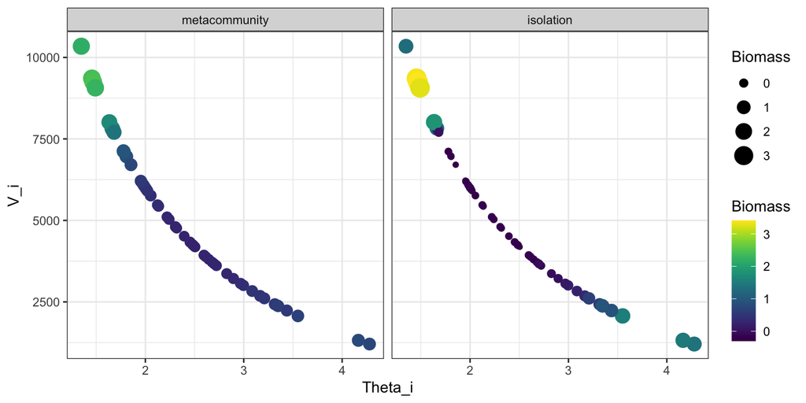

```r
lindsay.communities <- lindsay %>%
    filter(Ninitial == 32,
           Year %in% c(100, 200)) %>%
    group_by(Stage, SpeciesID, thetai, Vi) %>%
    summarise(mean.biomass = mean(Biomass))

ggplot(lindsay.communities) +
    geom_point(aes(x = thetai,
                   y = Vi,
                   color = log(mean.biomass),
                   size = log(mean.biomass))) +
    facet_grid(cols = vars(Stage)) +
    scale_color_viridis() +
    labs(x = "Theta_i",
         y = "V_i",
         color = "Biomass",
         size = "Biomass") +
    theme_bw()
```

In the 32-species mixture, seed addition tends to artificially increase the biomass of species with the moderate trait values. After seed addition is discontinued, species at the ends of the gradient tend to come to dominance. However, no species are extirpated from the simulation. Summing each species’ average biomass, the total average biomass during the metacommunity phase is `154`, while during the isolation phase it is `167`.

# 3 Biomass in mixture vs. biomass in monoculture

Next I plot the relationship between biomass in monoculture and biomass in mixture.

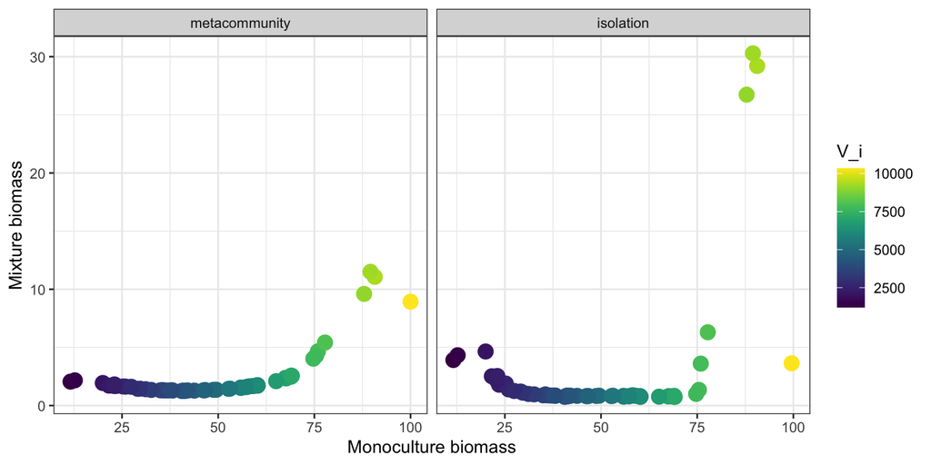

```r
lindsay.monoculture.vs.mixture <- lindsay %>%
    filter(Ninitial %in% c(1, 32),
           Year %in% c(100, 200)) %>%
    group_by(Ninitial, Stage, SpeciesID, thetai, Vi) %>%
    summarise(mean.biomass = mean(Biomass))

lindsay.monoculture.vs.mixture <- lindsay.monoculture.vs.mixture %>%
    pivot_wider(names_from = Ninitial,
                values_from = mean.biomass)

ggplot(lindsay.monoculture.vs.mixture) +
    geom_point(aes(x = `1`,
                   y = `32`,
                   color = Vi),
               size = 4) +
    facet_grid(cols = vars(Stage)) +
    scale_color_viridis() +
    labs(x = "Monoculture biomass",
         y = "Mixture biomass",
         color = "V_i") +
    theme_bw()
```

With seed addition, there is a direct relationship between monoculture biomass and mixture biomass. Removing external seed addition, species with moderate values along the trade-off gradient see reductions within their biomass in mixutre, relative to their monoculture biomasses.